# SupervisedLearning_Project_Part1_ShriyaNatesan

#### Data pre-processing

```python
feature_columns = ['P_incidence', 'P_tilt', 'L_angle','S_slope','P_radius','S_Degree']
X = med_fin[feature_columns]
y = med_fin['Class']
```

```python
X
```

|  | P_incidence | P_tilt | L_angle | S_slope | P_radius | S_Degree |
| --- | --- | --- | --- | --- | --- | --- |
| 0 | 38.505273 | 16.964297 | 35.112814 | 21.540976 | 127.632875 | 7.986683 |
| 1 | 54.920858 | 18.968430 | 51.601455 | 35.952428 | 125.846646 | 2.001642 |
| 2 | 44.362490 | 8.945435 | 46.902096 | 35.417055 | 129.220682 | 4.994195 |
| 3 | 48.318931 | 17.452121 | 48.000000 | 30.866809 | 128.980308 | -0.910941 |
| 4 | 45.701789 | 10.659859 | 42.577846 | 35.041929 | 130.178314 | -3.388910 |
| ... | ... | ... | ... | ... | ... | ... |
| 145 | 80.111572 | 33.942432 | 85.101608 | 46.169139 | 125.593624 | 100.292107 |
| 146 | 95.480229 | 46.550053 | 59.000000 | 48.930176 | 96.683903 | 77.283072 |
| 147 | 74.094731 | 18.823727 | 76.032156 | 55.271004 | 128.405731 | 73.388216 |
| 148 | 87.679087 | 20.365613 | 93.822416 | 67.313473 | 120.944829 | 76.730629 |
| 149 | 48.259920 | 16.417462 | 36.329137 | 31.842457 | 94.882336 | 28.343799 |

300 rows × 6 columns

```python
y
```

```
0      Normal
1      Normal
2      Normal
3      Normal
4      Normal
        ...
145    Type_S
146    Type_S
147    Type_S
148    Type_S
149    Type_S
Name: Class, Length: 300, dtype: object
```

```python
#Using label encoding for class values
from sklearn.preprocessing import LabelEncoder
le = LabelEncoder()
y = le.fit_transform(y)
```

```python
med_fin['Class'] = y
med_fin
```

|  | P_incidence | P_tilt | L_angle | S_slope | P_radius | S_Degree | Class |
| --- | --- | --- | --- | --- | --- | --- | --- |
| 0 | 38.505273 | 16.964297 | 35.112814 | 21.540976 | 127.632875 | 7.986683 | 0 |
| 1 | 54.920858 | 18.968430 | 51.601455 | 35.952428 | 125.846646 | 2.001642 | 0 |
| 2 | 44.362490 | 8.945435 | 46.902096 | 35.417055 | 129.220682 | 4.994195 | 0 |
| 3 | 48.318931 | 17.452121 | 48.000000 | 30.866809 | 128.980308 | -0.910941 | 0 |
| 4 | 45.701789 | 10.659859 | 42.577846 | 35.041929 | 130.178314 | -3.388910 | 0 |
| ... | ... | ... | ... | ... | ... | ... | ... |
| 145 | 80.111572 | 33.942432 | 85.101608 | 46.169139 | 125.593624 | 100.292107 | 2 |
| 146 | 95.480229 | 46.550053 | 59.000000 | 48.930176 | 96.683903 | 77.283072 | 2 |
| 147 | 74.094731 | 18.823727 | 76.032156 | 55.271004 | 128.405731 | 73.388216 | 2 |
| 148 | 87.679087 | 20.365613 | 93.822416 | 67.313473 | 120.944829 | 76.730629 | 2 |
| 149 | 48.259920 | 16.417462 | 36.329137 | 31.842457 | 94.882336 | 28.343799 | 2 |

300 rows × 7 columns

### Using normlaization and scaling to scale data

```python
#normalization of data
from sklearn import preprocessing

normalized_X = pd.DataFrame(preprocessing.normalize(X))
normalized_X.columns = X.columns
normalized_X
```

|  | P_incidence | P_tilt | L_angle | S_slope | P_radius | S_Degree |
| --- | --- | --- | --- | --- | --- | --- |
| 0 | 0.273498 | 0.120495 | 0.249402 | 0.153003 | 0.906560 | 0.056728 |
| 1 | 0.360785 | 0.124607 | 0.338979 | 0.236178 | 0.826709 | 0.013149 |
| 2 | 0.297573 | 0.060004 | 0.314608 | 0.237569 | 0.866782 | 0.033500 |
| 3 | 0.321892 | 0.116263 | 0.319767 | 0.205629 | 0.859243 | -0.006069 |
| 4 | 0.306724 | 0.071543 | 0.285758 | 0.235181 | 0.873680 | -0.022744 |
| ... | ... | ... | ... | ... | ... | ... |
| 295 | 0.387342 | 0.164113 | 0.411469 | 0.223229 | 0.607249 | 0.484916 |
| 296 | 0.529800 | 0.258297 | 0.327379 | 0.271504 | 0.536479 | 0.428828 |
| 297 | 0.387543 | 0.098455 | 0.397676 | 0.289088 | 0.671610 | 0.383848 |
| 298 | 0.428078 | 0.099432 | 0.458072 | 0.328646 | 0.590492 | 0.374624 |
| 299 | 0.397523 | 0.135233 | 0.299248 | 0.262290 | 0.781558 | 0.233472 |

300 rows × 6 columns

```python
#standardization of data using StandardScaler
from sklearn import preprocessing
from sklearn.preprocessing import StandardScaler

X_std = pd.DataFrame(StandardScaler().fit_transform(X))
X_std.columns = X.columns
X_std
```

|  | P_incidence | P_tilt | L_angle | S_slope | P_radius | S_Degree |
| --- | --- | --- | --- | --- | --- | --- |
| 0 | -1.276420 | -0.005546 | -0.897198 | -1.681015 | 0.787209 | -0.555064 |
| 1 | -0.295987 | 0.204878 | 0.016398 | -0.544639 | 0.649908 | -0.788794 |
| 2 | -0.926593 | -0.847486 | -0.243982 | -0.586855 | 0.909258 | -0.671928 |
| 3 | -0.690292 | 0.045673 | -0.183150 | -0.945652 | 0.890782 | -0.902538 |
| 4 | -0.846602 | -0.667480 | -0.483579 | -0.616434 | 0.982868 | -0.999309 |
| ... | ... | ... | ... | ... | ... | ... |
| 295 | 1.208547 | 1.777073 | 1.872561 | 0.260972 | 0.630459 | 3.049691 |
| 296 | 2.126451 | 3.100811 | 0.426333 | 0.478686 | -1.591734 | 2.151131 |
| 297 | 0.849187 | 0.189685 | 1.370044 | 0.978675 | 0.846616 | 1.999028 |
| 298 | 1.660522 | 0.351575 | 2.355760 | 1.928252 | 0.273121 | 2.129557 |
| 299 | -0.693816 | -0.062961 | -0.829805 | -0.868720 | -1.730215 | 0.239932 |

300 rows × 6 columns

### Creating train and test Data

```python
#USING STD SCALED DATA
import numpy as np
from sklearn.model_selection import train_test_split

# split into train and test
X_train, X_test, y_train, y_test = train_test_split(X_std, y, test_size=0.2, random_state=7)
```

```python
print(X_train.shape)
print(y_train.shape)
```

```
(240, 6)
(240,)
```

```python
print(X_test.shape)
print(y_test.shape)
```

```
(60, 6)
(60,)
```

#### Using the standard scaled data and evaluating model

```python
# loading library
from sklearn.neighbors import KNeighborsClassifier
from sklearn.metrics import accuracy_score

# instantiate learning model (k = 3)
knn = KNeighborsClassifier(n_neighbors = 3)

# fitting the model
knn.fit(X_train, y_train)

# predict the response
y_pred = knn.predict(X_train)

#Accuracy of train data
print("Accuracy of train data (k=3): ")
print(accuracy_score(y_train, y_pred))

# instantiate learning model (k = 3)
knn = KNeighborsClassifier(n_neighbors = 3)

# fitting the model
knn.fit(X_train, y_train)

# predict the response
y_pred = knn.predict(X_test)

# evaluate accuracy
print("Accuracy of test data (k=3): ")
print(accuracy_score(y_test, y_pred))

# instantiate learning model (k = 5)
knn = KNeighborsClassifier(n_neighbors = 5)

# fitting the model
knn.fit(X_train, y_train)

# predict the response
y_pred = knn.predict(X_train)

#Accuracy of train data
print("Accuracy of train data (k=5): ")
print(accuracy_score(y_train, y_pred))


# instantiate learning model (k = 5)
knn = KNeighborsClassifier(n_neighbors=5)

# fitting the model
knn.fit(X_train, y_train)

# predict the response
y_pred = knn.predict(X_test)

# evaluate accuracy
print("Accuracy of test data (k=5): ")
print(accuracy_score(y_test, y_pred))

# instantiate learning model (k = 5)
knn = KNeighborsClassifier(n_neighbors = 9)

# fitting the model
knn.fit(X_train, y_train)

# predict the response
y_pred = knn.predict(X_train)

#Accuracy of train data
print("Accuracy of train data (k=9): ")
print(accuracy_score(y_train, y_pred))

# instantiate learning model (k = 9)
knn = KNeighborsClassifier(n_neighbors=9)

# fitting the model
knn.fit(X_train, y_train)

# predict the response
y_pred = knn.predict(X_test)

# evaluate accuracy
print("Accuracy of test data (k=9): ")
print(accuracy_score(y_test, y_pred))
```

```
Accuracy of train data (k=3):
0.8791666666666667
Accuracy of test data (k=3):
0.8333333333333334
Accuracy of train data (k=5):
0.85
Accuracy of test data (k=5):
0.85
Accuracy of train data (k=9):
0.825
Accuracy of test data (k=9):
0.8333333333333334
```

```python
# empty list that will hold accuracy scores
ac_scores = []

# perform accuracy metrics for values from 1,3,5....49
for k in range(1,20,2):
    knn = KNeighborsClassifier(n_neighbors=k)
    knn.fit(X_train, y_train)
    # predict the response
    y_pred = knn.predict(X_test)
    # evaluate accuracy
    scores = accuracy_score(y_test, y_pred)
    ac_scores.append(scores)
```

```python
ac_scores
```

```
[0.8833333333333333,
 0.8333333333333334,
 0.85,
 0.8166666666666667,
 0.8333333333333334,
 0.85,
 0.8333333333333334,
 0.85,
 0.85,
 0.85]
```

```python
# subsetting just the odd ones
neighbors = list(range(1,20,2))

# changing to misclassification error
MSE = [1 - x for x in ac_scores]

# determining best k
optimal_k = neighbors[MSE.index(min(MSE))]
print("The optimal number of neighbors is %d" % optimal_k)
```

```
The optimal number of neighbors is 1
```

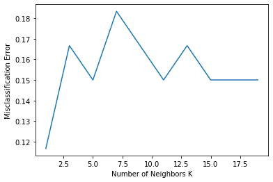

```python
import matplotlib.pyplot as plt
# plot misclassification error vs k
plt.plot(neighbors, MSE)
plt.xlabel('Number of Neighbors K')
plt.ylabel('Misclassification Error')
plt.show()
```

```python
#USING NORAMALIZED DATA
import numpy as np
from sklearn.model_selection import train_test_split

# split into train and test
X_train, X_test, y_train, y_test = train_test_split(normalized_X, y, test_size=0.2, random_state=7)
```

#### Using the normalized data and evaluating model

```python
# loading library
from sklearn.neighbors import KNeighborsClassifier
from sklearn.metrics import accuracy_score

# instantiate learning model (k = 3)
knn = KNeighborsClassifier(n_neighbors = 3)

# fitting the model
knn.fit(X_train, y_train)

# predict the response
y_pred = knn.predict(X_test)

# evaluate accuracy
print(accuracy_score(y_test, y_pred))

# instantiate learning model (k = 5)
knn = KNeighborsClassifier(n_neighbors=5)

# fitting the model
knn.fit(X_train, y_train)

# predict the response
y_pred = knn.predict(X_test)

# evaluate accuracy
print(accuracy_score(y_test, y_pred))

# instantiate learning model (k = 9)
knn = KNeighborsClassifier(n_neighbors=9)

# fitting the model
knn.fit(X_train, y_train)

# predict the response
y_pred = knn.predict(X_test)

# evaluate accuracy
print(accuracy_score(y_test, y_pred))
```

```
0.8166666666666667
0.8333333333333334
0.75
```

```python
# empty list that will hold accuracy scores
ac_scores = []

# perform accuracy metrics for values from 1,3,5....49
for k in range(1,20,2):
    knn = KNeighborsClassifier(n_neighbors=k)
    knn.fit(X_train, y_train)
    # predict the response
    y_pred = knn.predict(X_test)
    # evaluate accuracy
    scores = accuracy_score(y_test, y_pred)
    ac_scores.append(scores)
```

```python
ac_scores
```

```
[0.8166666666666667,
 0.8166666666666667,
 0.8333333333333334,
 0.75,
 0.75,
 0.8,
 0.75,
 0.7333333333333333,
 0.7333333333333333,
 0.75]
```

```python
# subsetting just the odd ones
neighbors = list(range(1,20,2))

# changing to misclassification error
MSE = [1 - x for x in ac_scores]

# determining best k
optimal_k = neighbors[MSE.index(min(MSE))]
print("The optimal number of neighbors is %d" % optimal_k)
```

```
The optimal number of neighbors is 5
```

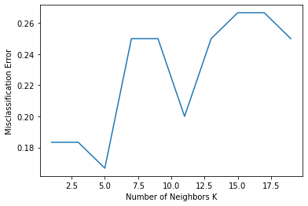

```python
import matplotlib.pyplot as plt
# plot misclassification error vs k
plt.plot(neighbors, MSE)
plt.xlabel('Number of Neighbors K')
plt.ylabel('Misclassification Error')
plt.show()
```

## Using standard scaled data we got an accuracy of 0.88, with an optimal value of k=1.

## Using normalized data we got an accuracy of 0.833, with an optimal value of k = 5.

#### Removing the redundant variables and recalculating accuracy

```python
X_std.corr()
```

|  | P_incidence | P_tilt | L_angle | S_slope | P_radius | S_Degree |
| --- | --- | --- | --- | --- | --- | --- |
| P_incidence | 1.000000 | 0.659119 | 0.763137 | 0.825235 | -0.294876 | 0.697539 |
| P_tilt | 0.659119 | 1.000000 | 0.401578 | 0.119185 | -0.059787 | 0.457465 |
| L_angle | 0.763137 | 0.401578 | 1.000000 | 0.705935 | -0.137680 | 0.710091 |
| S_slope | 0.825235 | 0.119185 | 0.705935 | 1.000000 | -0.344407 | 0.577358 |
| P_radius | -0.294876 | -0.059787 | -0.137680 | -0.344407 | 1.000000 | -0.172442 |
| S_Degree | 0.697539 | 0.457465 | 0.710091 | 0.577358 | -0.172442 | 1.000000 |

```python
data_New1 = X_std
data_New1['Class'] = y
data_New1.corr()

#So retaining S_Degree is important
#Can remove S_slope as its highly positively correlated to P_incidence and highly negatively correlated to P_radius
```

|  | P_incidence | P_tilt | L_angle | S_slope | P_radius | S_Degree | Class |
| --- | --- | --- | --- | --- | --- | --- | --- |
| P_incidence | 1.000000 | 0.659119 | 0.763137 | 0.825235 | -0.294876 | 0.697539 | 0.534065 |
| P_tilt | 0.659119 | 1.000000 | 0.401578 | 0.119185 | -0.059787 | 0.457465 | 0.322998 |
| L_angle | 0.763137 | 0.401578 | 1.000000 | 0.705935 | -0.137680 | 0.710091 | 0.522710 |
| S_slope | 0.825235 | 0.119185 | 0.705935 | 1.000000 | -0.344407 | 0.577358 | 0.462519 |
| P_radius | -0.294876 | -0.059787 | -0.137680 | -0.344407 | 1.000000 | -0.172442 | -0.360632 |
| S_Degree | 0.697539 | 0.457465 | 0.710091 | 0.577358 | -0.172442 | 1.000000 | 0.763279 |
| Class | 0.534065 | 0.322998 | 0.522710 | 0.462519 | -0.360632 | 0.763279 | 1.000000 |

```python
data_New1 = data_New1.drop(labels = "S_slope",axis = 1)
```

```python
feature_columns_New1 = ['P_incidence', 'P_tilt', 'L_angle','P_radius','S_Degree']
X_std_New = data_New1[feature_columns_New1]
y_New1 = data_New1['Class']
```

```python
#USING STD SCALED DATA WITHOUT S_slope
import numpy as np
from sklearn.model_selection import train_test_split

# split into train and test
X_train, X_test, y_train, y_test = train_test_split(X_std_New, y_New1, test_size=0.2, random_state=7)
```

```python
# loading library
from sklearn.neighbors import KNeighborsClassifier
from sklearn.metrics import accuracy_score

# instantiate learning model (k = 3)
knn = KNeighborsClassifier(n_neighbors = 3)

# fitting the model
knn.fit(X_train, y_train)

# predict the response
y_pred = knn.predict(X_train)

#Accuracy of train data
print("Accuracy of train data (k=3): ")
print(accuracy_score(y_train, y_pred))

# instantiate learning model (k = 3)
knn = KNeighborsClassifier(n_neighbors = 3)

# fitting the model
knn.fit(X_train, y_train)

# predict the response
y_pred = knn.predict(X_test)

# evaluate accuracy
print("Accuracy of test data (k=3): ")
print(accuracy_score(y_test, y_pred))

# instantiate learning model (k = 5)
knn = KNeighborsClassifier(n_neighbors = 5)

# fitting the model
knn.fit(X_train, y_train)

# predict the response
y_pred = knn.predict(X_train)

#Accuracy of train data
print("Accuracy of train data (k=5): ")
print(accuracy_score(y_train, y_pred))


# instantiate learning model (k = 5)
knn = KNeighborsClassifier(n_neighbors=5)

# fitting the model
knn.fit(X_train, y_train)

# predict the response
y_pred = knn.predict(X_test)

# evaluate accuracy
print("Accuracy of test data (k=5): ")
print(accuracy_score(y_test, y_pred))

# instantiate learning model (k = 5)
knn = KNeighborsClassifier(n_neighbors = 9)

# fitting the model
knn.fit(X_train, y_train)

# predict the response
y_pred = knn.predict(X_train)

#Accuracy of train data
print("Accuracy of train data (k=9): ")
print(accuracy_score(y_train, y_pred))

# instantiate learning model (k = 9)
knn = KNeighborsClassifier(n_neighbors=9)

# fitting the model
knn.fit(X_train, y_train)

# predict the response
y_pred = knn.predict(X_test)

# evaluate accuracy
print("Accuracy of test data (k=9): ")
print(accuracy_score(y_test, y_pred))
```

```
Accuracy of train data (k=3):
0.8791666666666667
Accuracy of test data (k=3):
0.8666666666666667
Accuracy of train data (k=5):
0.8666666666666667
Accuracy of test data (k=5):
0.8666666666666667
Accuracy of train data (k=9):
0.8333333333333334
Accuracy of test data (k=9):
0.8333333333333334
```

```python
# empty list that will hold accuracy scores
ac_scores = []

# perform accuracy metrics for values from 1,3,5....49
for k in range(1,20,2):
    knn = KNeighborsClassifier(n_neighbors=k)
    knn.fit(X_train, y_train)
    # predict the response
    y_pred = knn.predict(X_test)
    # evaluate accuracy
    scores = accuracy_score(y_test, y_pred)
    ac_scores.append(scores)
```

```python
ac_scores
```

```
[0.9166666666666666,
 0.8666666666666667,
 0.8666666666666667,
 0.85,
 0.8333333333333334,
 0.8333333333333334,
 0.8333333333333334,
 0.8333333333333334,
 0.8166666666666667,
 0.8333333333333334]
```

```python
# subsetting just the odd ones
neighbors = list(range(1,20,2))

# changing to misclassification error
MSE = [1 - x for x in ac_scores]

# determining best k
optimal_k = neighbors[MSE.index(min(MSE))]
print("The optimal number of neighbors is %d" % optimal_k)
```

```
The optimal number of neighbors is 1
```

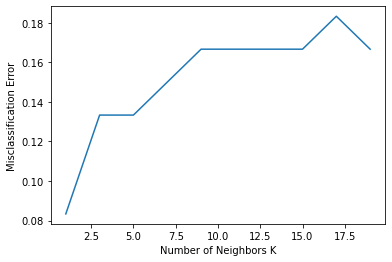

```python
import matplotlib.pyplot as plt
# plot misclassification error vs k
plt.plot(neighbors, MSE)
plt.xlabel('Number of Neighbors K')
plt.ylabel('Misclassification Error')
plt.show()
```

## As we can see, as soon as correlated variables were removed the accuracy increased to 0.91 for Standard scaled data with optimal value of k = 1.

```python
#Use k=1 as the final model for prediction
knn = KNeighborsClassifier(n_neighbors = 1)

# fitting the model
knn.fit(X_train, y_train)

# predict the response
y_pred = knn.predict(X_test)

# evaluate accuracy
print(accuracy_score(y_test, y_pred))
```

```
0.9166666666666666
```

```python
# For every test data point, predict it's label based on 5 nearest neighbours in this model. The majority class will
# be assigned to the test data point
NNH = KNeighborsClassifier(n_neighbors= 1 , weights = 'distance' )

# Call Nearest Neighbour algorithm

NNH.fit(X_train, y_train)

predicted_labels = NNH.predict(X_test)
NNH.score(X_test, y_test)
```

```
0.9166666666666666
```

```
Confusion Matrix
```

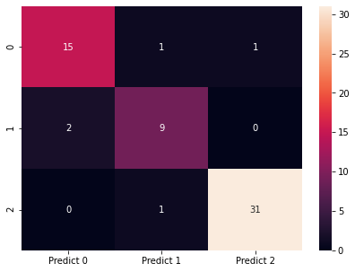

```python
# calculate accuracy measures and confusion matrix
from sklearn import metrics

print("Confusion Matrix")
cm=metrics.confusion_matrix(y_test, predicted_labels, labels=[0, 1, 2])

df_cm = pd.DataFrame(cm, index = [i for i in [0,1,2]],
                  columns = [i for i in ["Predict 0","Predict 1","Predict 2"]])
plt.figure(figsize = (7,5))
sns.heatmap(df_cm, annot=True)
```

## Suggestions

1. The class variable values basically did not convey a proper meaning.
2. For a data analyst one could only understand that there were 3 classes, but which TP rate is more important was not significant.
3. Quality thus could have been better of data by elaborationg some information on the Class Attribute.
4. Quantity and Veracity could have been improved by having some more records of the class Type_H.